# STAT400-Project1

```r
female <- read.csv("female.csv")
head(female)
```

|  | Series.Name | Series.Code | Country.Name | Country.Code | X1990..YR1990. | X2000..YR2000. | X2013..YR2013. | X2014..YR2014. | X2015..YR2015. | X2016..YR2016. | X2017..YR2017. | X2018..YR2018. | X2019..YR2019. | X2020..YR2020. | X2021..YR2021. | X2022..YR2022. |
| --- | --- | --- | --- | --- | --- | --- | --- | --- | --- | --- | --- | --- | --- | --- | --- | --- |
| 1 | Account ownership at a financial institution or with a mobile-money-service provider, female (% of population ages 15+) | FX.OWN.TOTL.FE.ZS | Afghanistan | AFG | .. | .. | .. | 3.81 | .. | .. | 7.16 | .. | .. | .. | 4.7 | .. |
| 2 | Account ownership at a financial institution or with a mobile-money-service provider, female (% of population ages 15+) | FX.OWN.TOTL.FE.ZS | Albania | ALB | .. | .. | .. | 33.59 | .. | .. | 38.1 | .. | .. | .. | 45.69 | .. |
| 3 | Account ownership at a financial institution or with a mobile-money-service provider, female (% of population ages 15+) | FX.OWN.TOTL.FE.ZS | Algeria | DZA | .. | .. | .. | 40.07 | .. | .. | 29.27 | .. | .. | .. | 31.19 | .. |
| 4 | Account ownership at a financial institution or with a mobile-money-service provider, female (% of population ages 15+) | FX.OWN.TOTL.FE.ZS | American Samoa | ASM | .. | .. | .. | .. | .. | .. | .. | .. | .. | .. | .. | .. |
| 5 | Account ownership at a financial institution or with a mobile-money-service provider, female (% of population ages 15+) | FX.OWN.TOTL.FE.ZS | Andorra | AND | .. | .. | .. | .. | .. | .. | .. | .. | .. | .. | .. | .. |
| 6 | Account ownership at a financial institution or with a mobile-money-service provider, female (% of population ages 15+) | FX.OWN.TOTL.FE.ZS | Angola | AGO | .. | .. | .. | 22.33 | .. | .. | .. | .. | .. | .. | .. | .. |

```r
library(tidyverse)
female <- female %>%filter(Country.Name == "Brazil" | Country.Name == "India" | Country.Name == "United States")
head(female)
```

|  | Series.Name | Series.Code | Country.Name | Country.Code | X1990..YR1990. | X2000..YR2000. | X2013..YR2013. | X2014..YR2014. | X2015..YR2015. | X2016..YR2016. | X2017..YR2017. | X2018..YR2018. | X2019..YR2019. | X2020..YR2020. | X2021..YR2021. | X2022..YR2022. |
| --- | --- | --- | --- | --- | --- | --- | --- | --- | --- | --- | --- | --- | --- | --- | --- | --- |
| 1 | Account ownership at a financial institution or with a mobile-money-service provider, female (% of population ages 15+) | FX.OWN.TOTL.FE.ZS | Brazil | BRA | .. | .. | .. | 64.77 | .. | .. | 67.51 | .. | .. | .. | 80.87 | .. |
| 2 | Account ownership at a financial institution or with a mobile-money-service provider, female (% of population ages 15+) | FX.OWN.TOTL.FE.ZS | India | IND | .. | .. | .. | 43.13 | .. | .. | 76.64 | .. | .. | .. | 77.55 | .. |
| 3 | Account ownership at a financial institution or with a mobile-money-service provider, female (% of population ages 15+) | FX.OWN.TOTL.FE.ZS | United States | USA | .. | .. | .. | 94.8 | .. | .. | 92.69 | .. | .. | .. | 96.79 | .. |

```r
colnames(female)
```

```
 [1] "Series.Name"    "Series.Code"    "Country.Name"   "Country.Code"   "X1990..YR1990." "X2000..YR2000." "X2013..YR2013." "X2014..YR2014." "X2015..YR2015." "X2016..YR2016." "X2017..YR2017." "X2018..YR2018." "X2019..YR2019."
[14] "X2020..YR2020." "X2021..YR2021." "X2022..YR2022."
```

```r
rel_col <- which(colnames(female)=="Country.Name" | colnames(female)== "X2014..YR2014." | colnames(female)== "X2017..YR2017." | colnames(female) == "X2021..YR2021." )
rel_col
```

```
[1]  3  8 11 15
```

```r
female <- female[rel_col] %>% rename("2014" = 2, "2017" = 3, "2021" = 4)
head(female)
```

|  | Country.Name | 2014 | 2017 | 2021 |
| --- | --- | --- | --- | --- |
| 1 | Brazil | 64.77 | 67.51 | 80.87 |
| 2 | India | 43.13 | 76.64 | 77.55 |
| 3 | United States | 94.8 | 92.69 | 96.79 |

```r
transpose_f <- data.frame(t(female[-1]))
colnames(transpose_f) <- female[, 1]
head(transpose_f)
```

|  | Brazil | India | United States |
| --- | --- | --- | --- |
| 2014 | 64.77 | 43.13 | 94.8 |
| 2017 | 67.51 | 76.64 | 92.69 |
| 2021 | 80.87 | 77.55 | 96.79 |

```r
transpose_f$Brazil = as.numeric(transpose_f$Brazil)
transpose_f$India = as.numeric(transpose_f$India)
transpose_f$"United States" = as.numeric(transpose_f$"United States")
head(transpose_f)
```

|  | Brazil | India | United States |
| --- | --- | --- | --- |
| 2014 | 64.77 | 43.13 | 94.80 |
| 2017 | 67.51 | 76.64 | 92.69 |
| 2021 | 80.87 | 77.55 | 96.79 |

```r
transpose_f <- transpose_f %>% mutate_if(is.numeric, as.character)
head(transpose_f)
```

|  | Brazil | India | United States |
| --- | --- | --- | --- |
| 2014 | 64.77 | 43.13 | 94.8 |
| 2017 | 67.51 | 76.64 | 92.69 |
| 2021 | 80.87 | 77.55 | 96.79 |

```r
transpose_f <- transpose_f %>% mutate_if(is.character, as.numeric)
head(transpose_f)
```

|  | Brazil | India | United States |
| --- | --- | --- | --- |
| 2014 | 64.77 | 43.13 | 94.80 |
| 2017 | 67.51 | 76.64 | 92.69 |
| 2021 | 80.87 | 77.55 | 96.79 |

```r
summarise_each(transpose_f, list(mean))
```

| Brazil | India | United States |
| --- | --- | --- |
| 71.05 | 65.77333 | 94.76 |

```r
transpose_f %>%
  summarise(across(c(Brazil, India, "United States"), list(mean=mean, sd=sd)))
```

| Brazil_mean | Brazil_sd | India_mean | India_sd | United States_mean | United States_sd |
| --- | --- | --- | --- | --- | --- |
| 71.05 | 8.614012 | 65.77333 | 19.61498 | 94.76 | 2.050293 |

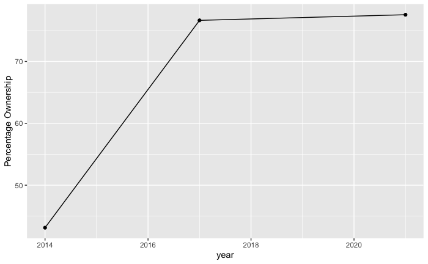

```r
year <- c(2014, 2017,2021)
p <- ggplot(data=transpose_f, aes(x=year, y=India, group=1)) +
  geom_line()+
  geom_point()
  p + ylab("Percentage Ownership")
```

```r
male <- read.csv(file = "male.csv")
male <- male %>%
  filter(Country.Name == "Brazil" | Country.Name == "India" | Country.Name == "United States")

male <- male[rel_col] %>%
  rename("2014" = 2, "2017" = 3, "2021" = 4)

transpose_m <- data.frame(t(male[-1]))
colnames(transpose_m) <- male[, 1]

transpose_m$Brazil = as.numeric(as.character(transpose_m$Brazil))
transpose_m$India = as.numeric(as.character(transpose_m$India))
transpose_m$"United States" = as.numeric(as.character((transpose_m$"United States")))

head(transpose_m)
```

|  | Brazil | India | United States |
| --- | --- | --- | --- |
| 2014 | 71.69 | 62.76 | 92.36 |
| 2017 | 72.85 | 83.01 | 93.57 |
| 2021 | 87.05 | 77.51 | 93.09 |

```r
transpose_m <- rename(transpose_m, "Brazil_m" = 1, "India_m" = 2, "United_States_m" = 3)
head(transpose_m)
```

|  | Brazil_m | India_m | United_States_m |
| --- | --- | --- | --- |
| 2014 | 71.69 | 62.76 | 92.36 |
| 2017 | 72.85 | 83.01 | 93.57 |
| 2021 | 87.05 | 77.51 | 93.09 |

```r
transpose_m <- rownames_to_column(transpose_m, var="Year")
transpose_f <- rownames_to_column(transpose_f, var="Year")

acct_owner_by_gender <- merge(x = transpose_m, y = transpose_f, by = "Year", all.x = TRUE)
acct_owner_by_gender <- rename(acct_owner_by_gender, "United_States" = 7)
head(acct_owner_by_gender)
```

|  | Year | Brazil_m | India_m | United_States_m | Brazil | India | United_States |
| --- | --- | --- | --- | --- | --- | --- | --- |
| 1 | 2014 | 71.69 | 62.76 | 92.36 | 64.77 | 43.13 | 94.80 |
| 2 | 2017 | 72.85 | 83.01 | 93.57 | 67.51 | 76.64 | 92.69 |
| 3 | 2021 | 87.05 | 77.51 | 93.09 | 80.87 | 77.55 | 96.79 |

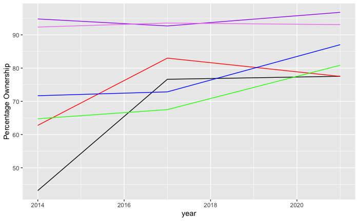

```r
gfg_plot <- ggplot(acct_owner_by_gender, aes(x=year)) +
    geom_line(aes(y = India), color = "black") +
    geom_line(aes(y = India_m), color = "red") +
    geom_line(aes(y = Brazil), color = "green") +
    geom_line(aes(y = Brazil_m), color = "blue") +
    geom_line(aes(y = United_States), color = "purple") +
    geom_line(aes(y = United_States_m), color = "violet")
    gfg_plot + ylab("Percentage Ownership")
```

1. y-axis labels changed in plots above using ylab(“Percentage Ownership”)
2. Based on the plot, account ownership has been generally on the rise in recent years, with the exception of males from India. It is interesting that the data shows how there is a higher percentage of male account ownership than female, except for in the United States.
3. If 2017 is disregarded, one could not with certainty say that account percentages ahvve been increasing due to India decreasing afterwards.
4. Below:

```r
primary <- read.csv("primary.csv")
primary <- primary %>%filter(Country.Name == "China" | Country.Name == "Canada" | Country.Name == "Germany" | Country.Name == "United Kingdom" | Country.Name == "Spain")
rel_col <- which(colnames(primary)=="Country.Name" | colnames(primary)== "X2014..YR2014." | colnames(primary)== "X2017..YR2017." | colnames(primary) == "X2021..YR2021." )
primary <- primary[rel_col] %>% rename("2014" = 2, "2017" = 3, "2021" = 4)
transpose_p <- data.frame(t(primary[-1]))
colnames(transpose_p) <- primary[, 1]
transpose_p$China = as.numeric(transpose_p$China)
transpose_p$Canada = as.numeric(transpose_p$Canada)
transpose_p$Germany = as.numeric(transpose_p$Germany)
transpose_p$"United Kingdom" = as.numeric(transpose_p$"United Kingdom")
transpose_p$Spain = as.numeric(transpose_p$Spain)

transpose_p <- transpose_p %>% mutate_if(is.numeric, as.character)
transpose_p <- transpose_p %>% mutate_if(is.character, as.numeric)
summarise_each(transpose_p, list(mean))
```

| Canada | China | Germany | Spain | United Kingdom |
| --- | --- | --- | --- | --- |
| 94.96333 | 75.74333 | 99.21333 | 92.85333 | 96.18333 |

```r
transpose_p %>%
  summarise(across(c(Canada, China, "United Kingdom", Germany, Spain), list(mean=mean, sd=sd)))
```

| Canada_mean | Canada_sd | China_mean | China_sd | United Kingdom_mean | United Kingdom_sd | Germany_mean | Germany_sd | Spain_mean | Spain_sd |
| --- | --- | --- | --- | --- | --- | --- | --- | --- | --- |
| 94.96333 | 4.924148 | 75.74333 | 6.34221 | 96.18333 | 5.231466 | 99.21333 | 1.362547 | 92.85333 | 3.685218 |

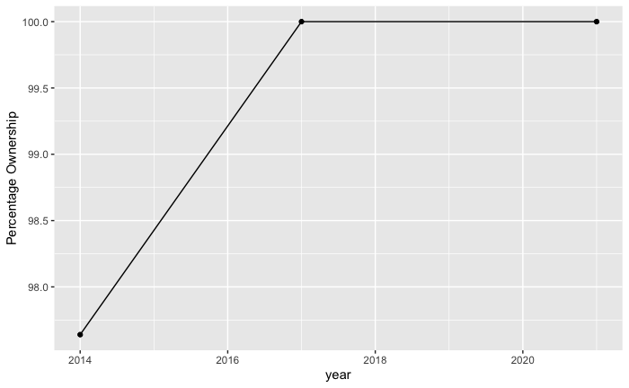

```r
year <- c(2014, 2017,2021)
p <- ggplot(data=transpose_p, aes(x=year, y=Germany, group=1)) +
  geom_line()+
  geom_point()
  p + ylab("Percentage Ownership")
```

```r
secondary <- read.csv(file = "secondary.csv")
secondary <- secondary %>%
  filter(Country.Name == "Germany" | Country.Name == "China" | Country.Name == "United Kingdom" | Country.Name == "Spain" | Country.Name == "Canada")

secondary <- secondary[rel_col] %>%
  rename("2014" = 2, "2017" = 3, "2021" = 4)

transpose_s <- data.frame(t(secondary[-1]))
colnames(transpose_s) <- secondary[, 1]

transpose_s$Germany = as.numeric(as.character(transpose_s$Germany))
transpose_s$China = as.numeric(as.character(transpose_s$China))
transpose_s$"United Kingdom" = as.numeric(as.character((transpose_s$"United Kingdom")))
transpose_s$Spain = as.numeric(as.character(transpose_s$Spain))
transpose_s$Canada = as.numeric(as.character(transpose_s$Canada))

head(transpose_s)
```

|  | Canada | China | Germany | Spain | United Kingdom |
| --- | --- | --- | --- | --- | --- |
| 2014 | 99.57 | 89.84 | 98.80 | 98.09 | 98.84 |
| 2017 | 99.87 | 94.14 | 99.30 | 95.84 | 97.77 |
| 2021 | 99.88 | 97.21 | 99.97 | 98.80 | 99.95 |

```r
transpose_s <- rename(transpose_s, "Canada_s" = 1, "China_s" = 2, "Germany_s" = 3, "Spain_s" = 4, "United_Kingdom_s" = 5)
head(transpose_s)
```

|  | Canada_s | China_s | Germany_s | Spain_s | United_Kingdom_s |
| --- | --- | --- | --- | --- | --- |
| 2014 | 99.57 | 89.84 | 98.80 | 98.09 | 98.84 |
| 2017 | 99.87 | 94.14 | 99.30 | 95.84 | 97.77 |
| 2021 | 99.88 | 97.21 | 99.97 | 98.80 | 99.95 |

```r
transpose_s <- rownames_to_column(transpose_s, var="Year")
transpose_p <- rownames_to_column(transpose_p, var="Year")

acct_owner_by_gender <- merge(x = transpose_s, y = transpose_p, by = "Year", all.x = TRUE)
acct_owner_by_gender <- rename(acct_owner_by_gender, "United_Kingdom" = 11)
head(acct_owner_by_gender)
```

|  | Year | Canada_s | China_s | Germany_s | Spain_s | United_Kingdom_s | Canada | China | Germany | Spain | United_Kingdom |
| --- | --- | --- | --- | --- | --- | --- | --- | --- | --- | --- | --- |
| 1 | 2014 | 99.57 | 89.84 | 98.80 | 98.09 | 98.84 | 100.00 | 72.82 | 97.64 | 93.17 | 100.00 |
| 2 | 2017 | 99.87 | 94.14 | 99.30 | 95.84 | 97.77 | 94.73 | 71.39 | 100.00 | 89.02 | 90.22 |
| 3 | 2021 | 99.88 | 97.21 | 99.97 | 98.80 | 99.95 | 90.16 | 83.02 | 100.00 | 96.37 | 98.33 |

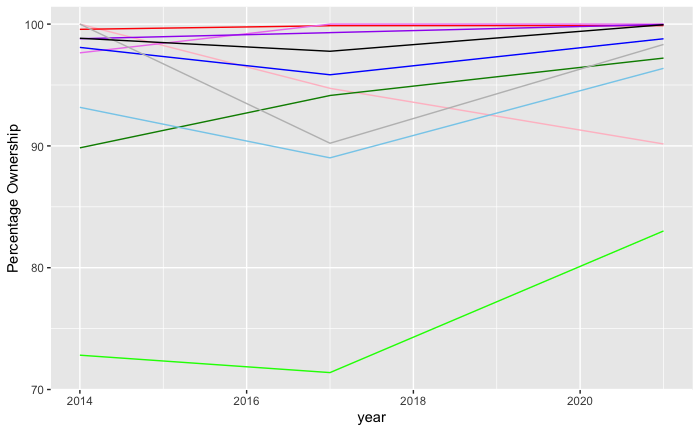

```r
gfg_plot <- ggplot(acct_owner_by_gender, aes(x=year)) +
    geom_line(aes(y = Canada), color = "pink") +
    geom_line(aes(y = Canada_s), color = "red") +
    geom_line(aes(y = China), color = "green") +
    geom_line(aes(y = China_s), color = "green4") +
    geom_line(aes(y = Germany), color = "violet") +
    geom_line(aes(y = Germany_s), color = "purple") +
    geom_line(aes(y = Spain), color = "skyblue") +
    geom_line(aes(y = Spain_s), color = "blue") +
    geom_line(aes(y = United_Kingdom), color = "gray") +
    geom_line(aes(y = United_Kingdom_s), color = "black")
    gfg_plot + ylab("Percentage Ownership")
```

The outputs given by analyzing the data of account ownership dependent on education level seems to have a similar change in 2017. A number of groups analyzed change direction during this year, but there isn’t much correlation shown relating to education level, as those with primary education in some countries exhibit tendencies that those in other countries with higher than a secondary education also show. The one major outlier is China with a primary education or less, as it stays around 10-20% lower than the rest of the groups in this analysis. Similar to the gender study, omitting 2017 would not allude to any conclusions about the the percentage of account ownership across different countries. However, if one country and education combination were to be focused on, it is possible a constant increase or decrease can be inferred.